# **Variation of Iris Data**

Jia-Yi Lin

2022-07-07

[figure not shown]

# **I. Motivation Question**

- Different type of data

# **II. Focus Problem**

- Model accuracy

# **III. Data and EDA**

#### **Source**

- [Multivariate Normal Data](https://mushroom11167.shinyapps.io/220622/)

#### **Variable**

- Simple
  - Four group
  - N = 400
  - $x_1$, $x_2$, $x_3$, $x_4$
  - First group mean is (1, 2, 3, 4)
  - Second group mean is (5, 6, 7, 8)
  - Third group mean is (9, 10, 11, 12)
  - Fourth group mean is (13, 14, 15, 16)
- Common
  - Four group
  - N = 400
  - $x_1$, $x_2$, $x_3$, $x_4$
  - First group mean is (1, 2, 3, 5)
  - Second group mean is (2, 4, 6, 9)
  - Third group mean is (10, 11, 12, 13)
  - Fourth group mean is (13, 11.5, 10.5, 15)
- Difficulty
  - Four group
  - N = 400
  - $x_1$, $x_2$, $x_3$ , $x_4$
  - First group mean is (1, 2, 5, 7)
  - Second group mean is (0.5, 1.5, 4.5, 6.5)
  - Third group mean is (0.25, 0.75, 2.25, 3.25)
  - Fourth group mean is (0.125, 0.375, 1.125, 1.625)
- Unbalance
  - Four group
  - $x_1$, $x_2$, $x_3$, $x_4$
  - First group N is 100
  - Second group N is 100
  - Third group N is 1000
  - Fourth group N is 500
  - First group mean is (1, 2, 3, 4)
  - Second group mean is (5, 6, 7, 8)
  - Third group mean is (10, 12, 14, 16)
  - Fourth group mean is (11, 13, 15, 17)

### **Simple**

|  | type | x1 | x2 | x3 | x4 |
| --- | --- | --- | --- | --- | --- |
| 1 | 1 | 1.48697078139414 | 2.01758146388649 | 3.30922624633545 | 4.70459170727193 |
| 2 | 1 | 1.19259998117366 | 2.23786405941095 | 3.29720859039883 | 4.17895105870775 |
| 3 | 1 | 3.31607986603638 | 1.80759773269409 | 3.89662284936624 | 4.71997063128912 |
| 4 | 1 | 1.02105783077341 | 3.16632794448911 | 1.82027818701234 | 4.56150756152178 |
| 5 | 1 | 1.29760736861489 | 1.75573273500277 | 0.504186146263536 | 3.32511237233147 |
| 6 | 1 | 1.8121483338374 | 3.44379387842485 | 2.98706007337806 | 4.102955915054 |
| 7 | 1 | 0.172682332904045 | 2.58589713691363 | 4.45150214293159 | 4.62184633708924 |
| 8 | 1 | 0.0621937071073826 | 1.95332502524533 | 3.88772775757018 | 2.65790299609844 |
| 9 | 1 | 2.50061623765207 | 2.44774277672551 | 4.3578536021479 | 3.65204694090397 |
| 10 | 1 | 0.925713679092614 | 1.67162771078807 | 1.96871462211319 | 3.68702594997025 |

[output cut: 390 more lines]

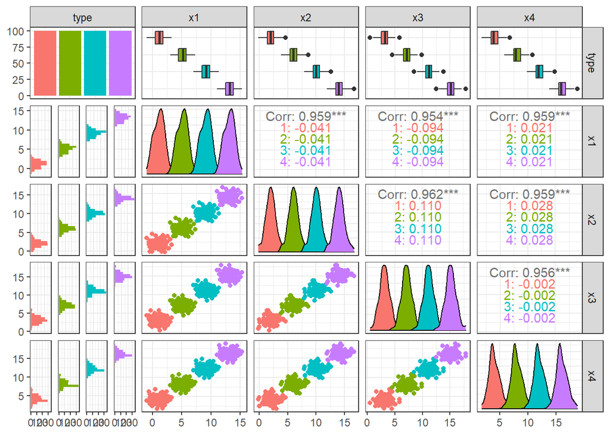

### **Common**

|  | type | x1 | x2 | x3 | x4 |
| --- | --- | --- | --- | --- | --- |
| 1 | 1 | 1.77369313325504 | 2.31783390854699 | 3.60173831997324 | 6.19772484353163 |
| 2 | 1 | 1.38526733318248 | 2.4859427309652 | 3.48254313888793 | 5.38663235467807 |
| 3 | 1 | 4.47117029580557 | 2.09787093815096 | 5.06765300425128 | 6.1370987642402 |
| 4 | 1 | 0.667102775233172 | 4.14658834140658 | 1.4261500519374 | 6.36346391943358 |
| 5 | 1 | 0.48289917725604 | 1.3036388881159 | -0.307133418689816 | 3.76406768062492 |
| 6 | 1 | 2.19411176730059 | 4.53341003227422 | 3.31548568152962 | 5.68006987980321 |
| 7 | 1 | 0.434358656776625 | 3.1967481193366 | 4.69549151825833 | 6.26949122823313 |
| 8 | 1 | 0.0514578307380715 | 1.40850136765643 | 3.86681702496317 | 2.7158074407566 |
| 9 | 1 | 3.57510056160806 | 2.76408980178005 | 5.41414968665408 | 4.55959436526513 |
| 10 | 1 | 0.503005357496226 | 1.30240452127826 | 1.55562008487064 | 4.35233896872375 |

[output cut: 390 more lines]

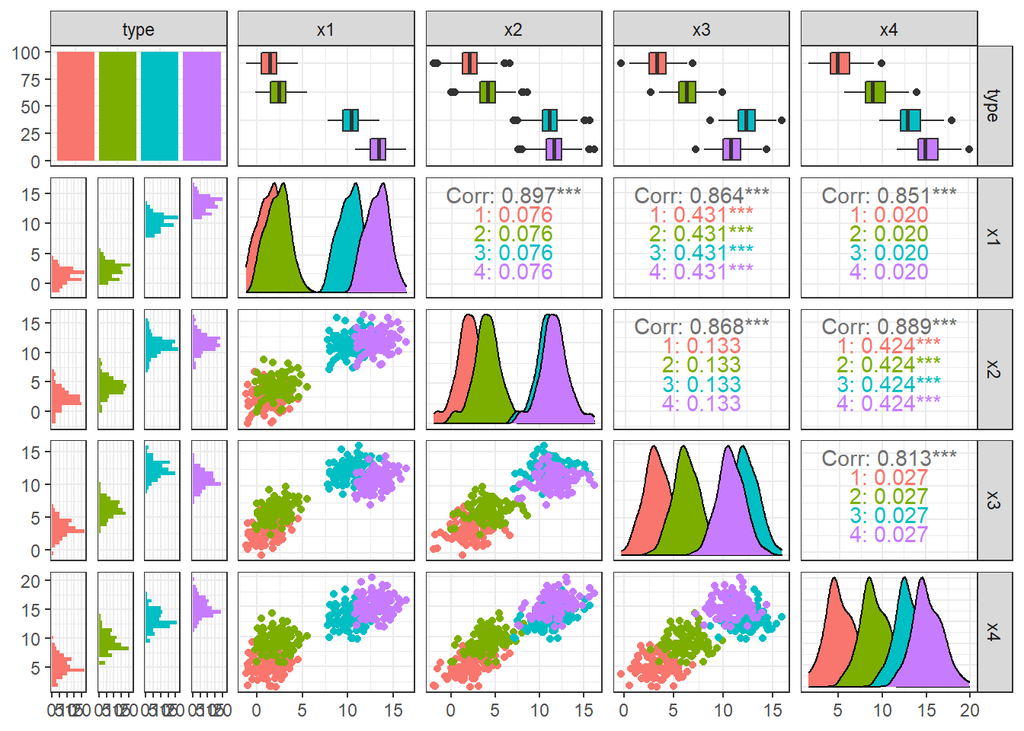

### **Difficulty**

|  | type | x1 | x2 | x3 | x4 |
| --- | --- | --- | --- | --- | --- |
| 1 | 1 | 1.77369313325504 | 2.31783390854699 | 5.60173831997324 | 8.19772484353163 |
| 2 | 1 | 1.38526733318248 | 2.4859427309652 | 5.48254313888793 | 7.38663235467807 |
| 3 | 1 | 4.47117029580557 | 2.09787093815096 | 7.06765300425128 | 8.1370987642402 |
| 4 | 1 | 0.667102775233172 | 4.14658834140658 | 3.4261500519374 | 8.36346391943358 |
| 5 | 1 | 0.48289917725604 | 1.3036388881159 | 1.69286658131018 | 5.76406768062492 |
| 6 | 1 | 2.19411176730059 | 4.53341003227422 | 5.31548568152962 | 7.68006987980321 |
| 7 | 1 | 0.434358656776625 | 3.1967481193366 | 6.69549151825833 | 8.26949122823313 |
| 8 | 1 | 0.0514578307380715 | 1.40850136765643 | 5.86681702496317 | 4.7158074407566 |
| 9 | 1 | 3.57510056160806 | 2.76408980178005 | 7.41414968665408 | 6.55959436526513 |
| 10 | 1 | 0.503005357496226 | 1.30240452127826 | 3.55562008487064 | 6.35233896872375 |

[output cut: 390 more lines]

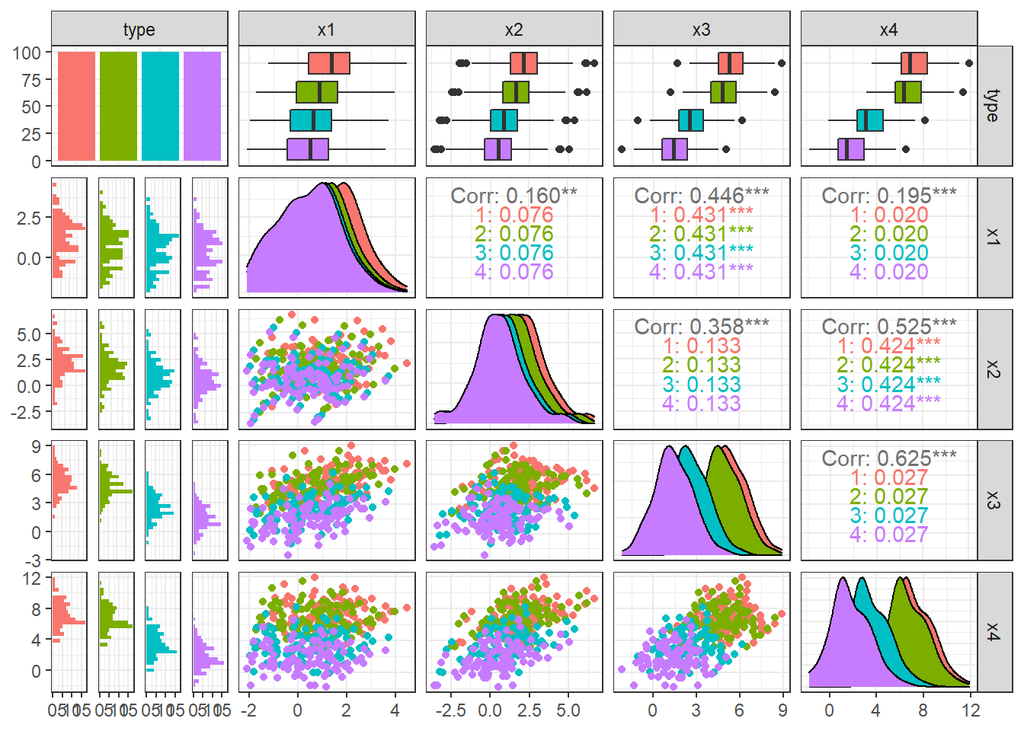

### **Unbalance**

|  | type | x1 | x2 | x3 | x4 |
| --- | --- | --- | --- | --- | --- |
| 1 | 1 | 1.77369313325504 | 2.31783390854699 | 3.60173831997324 | 5.19772484353163 |
| 2 | 1 | 1.38526733318248 | 2.4859427309652 | 3.48254313888793 | 4.38663235467807 |
| 3 | 1 | 4.47117029580557 | 2.09787093815096 | 5.06765300425128 | 5.1370987642402 |
| 4 | 1 | 0.667102775233172 | 4.14658834140658 | 1.4261500519374 | 5.36346391943358 |
| 5 | 1 | 0.48289917725604 | 1.3036388881159 | -0.307133418689816 | 2.76406768062492 |
| 6 | 1 | 2.19411176730059 | 4.53341003227422 | 3.31548568152962 | 4.68006987980321 |
| 7 | 1 | 0.434358656776626 | 3.1967481193366 | 4.69549151825833 | 5.26949122823313 |
| 8 | 1 | 0.0514578307380714 | 1.40850136765643 | 3.86681702496317 | 1.7158074407566 |
| 9 | 1 | 3.57510056160806 | 2.76408980178005 | 5.41414968665408 | 3.55959436526513 |
| 10 | 1 | 0.503005357496225 | 1.30240452127826 | 1.55562008487064 | 3.35233896872375 |

[output cut: 1690 more lines]

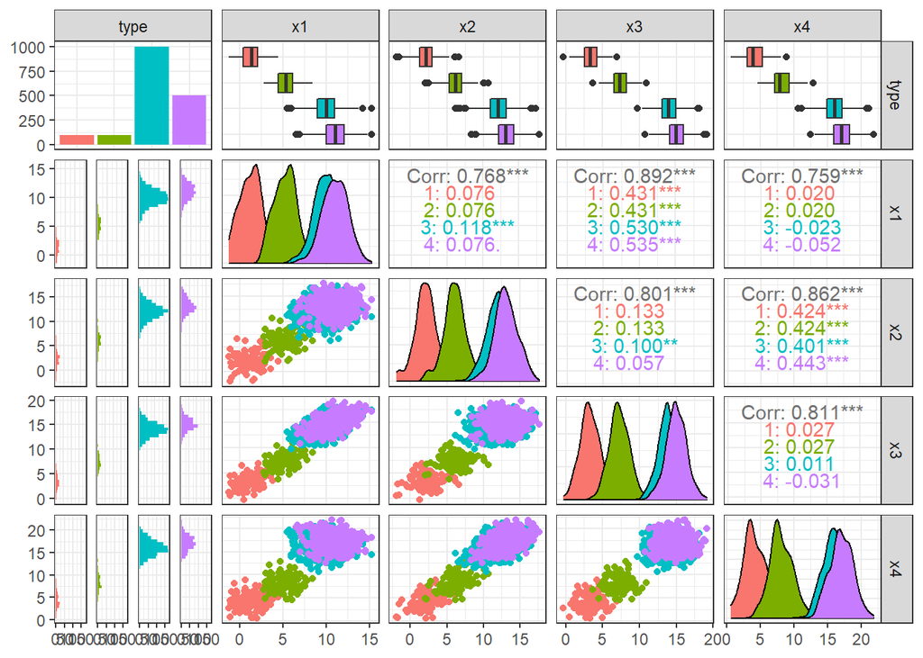

# **IV. Model**

Using **K-Fold Cross-Validation** divide the data into **five** part

## **Simple**

```r
easy.num <- kfcv(easy, seed=1116, k = 5)
```

### **CART**

```r
success <-0

for(i in 1:5){

  easy.train <- easy[-easy.num[[i]],]
  easy.test <- easy[easy.num[[i]],]

  easy.tree <- rpart(type ~., data = easy.train)

  tree.test.pred <- predict(easy.tree, newdata = easy.test, type="class")
  tree.test.table <- table(easy.test$type, tree.test.pred, dnn = c("actual", "predict"))
  correct.tree.test <- sum(diag(tree.test.table))
  correct.tree.test


  success <- success + correct.tree.test

}
```

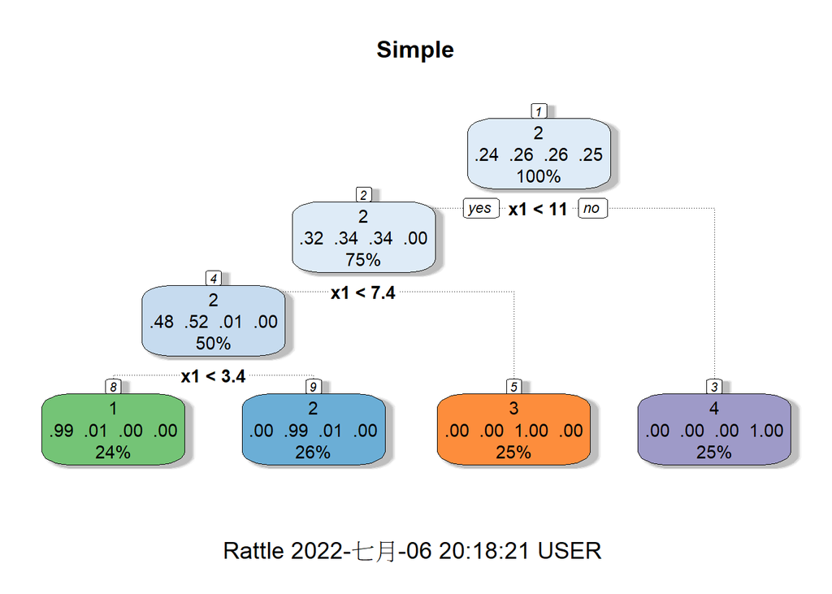

**Confusion Matrix**

```r
knitr::kable(tree.test.table,row.names = TRUE)
```

|  | 1 | 2 | 3 | 4 |
| --- | --- | --- | --- | --- |
| 1 | 24 | 0 | 0 | 0 |
| 2 | 0 | 18 | 0 | 0 |
| 3 | 0 | 0 | 18 | 0 |
| 4 | 0 | 0 | 1 | 19 |

**Testing data accuracy**

```r
(success/400)*100
```

```
## [1] 97.5
```

### **Random Forest**

```r
success <-0

for(i in 1:5){

  easy.train <- easy[-easy.num[[i]],]
  easy.test <- easy[easy.num[[i]],]

  easy.rf <- randomForest(type~., data = easy.train, ntree=500)
  rf.test.pred <- predict(easy.rf, newdata = easy.test)
  rf.test.table <- table(easy.test$type, rf.test.pred, dnn = c("actual", "pred"))
  correct.rf.test <- sum(diag(rf.test.table))
  correct.rf.test

  success <- success + correct.rf.test

}
```

**Confusion Matrix**

```r
knitr::kable(rf.test.table,row.names = TRUE)
```

|  | 1 | 2 | 3 | 4 |
| --- | --- | --- | --- | --- |
| 1 | 24 | 0 | 0 | 0 |
| 2 | 0 | 18 | 0 | 0 |
| 3 | 0 | 0 | 18 | 0 |
| 4 | 0 | 0 | 0 | 20 |

**Testing data accuracy**

```r
(success/400)*100
```

```
## [1] 99.75
```

### **SVM**

```r
success <-0

for(i in 1:5){

  easy.train <- easy[-easy.num[[i]],]
  easy.test <- easy[easy.num[[i]],]


  easy.svm <- svm(type~., data = easy.train)

  easy.svm.pred <- predict(easy.svm, easy.test)
  svm.test.table <- table(easy.test$type, easy.svm.pred, dnn = c("actual", "predict"))
  correct.svm.test <- sum(diag(svm.test.table))
  correct.svm.test

  success <- success + correct.svm.test

}
```

**Confusion Matrix**

```r
knitr::kable(svm.test.table,row.names = TRUE)
```

|  | 1 | 2 | 3 | 4 |
| --- | --- | --- | --- | --- |
| 1 | 24 | 0 | 0 | 0 |
| 2 | 0 | 18 | 0 | 0 |
| 3 | 0 | 0 | 18 | 0 |
| 4 | 0 | 0 | 0 | 20 |

**Testing data accuracy**

```r
(success/400)*100
```

```
## [1] 100
```

### **LDA**

```r
success <- 0

for(i in 1:5){

  easy.train <- easy[-easy.num[[i]],]
  easy.test <- easy[easy.num[[i]],]

  easy.lda <- lda(type ~., data = easy.train)

  easy.lda.pred <- predict(easy.lda, newdata = easy.test[,-1])$class
  lda.test.table <- table(easy.test$type, easy.lda.pred, dnn = c("actual", "predict"))
  correct.lda.test <- sum(diag(lda.test.table))
  correct.lda.test

  success <- success + correct.lda.test

}
```

**Confusion Matrix**

```r
knitr::kable(lda.test.table,row.names = TRUE)
```

|  | 1 | 2 | 3 | 4 |
| --- | --- | --- | --- | --- |
| 1 | 24 | 0 | 0 | 0 |
| 2 | 0 | 18 | 0 | 0 |
| 3 | 0 | 0 | 18 | 0 |
| 4 | 0 | 0 | 0 | 20 |

**Testing data accuracy**

```r
(success/400)*100
```

```
## [1] 100
```

## **Common**

```r
com.num <- kfcv(com, seed=1116, k = 5)
```

### **CART**

```r
success <-0

for(i in 1:5){

  com.train <- com[-com.num[[i]],]
  com.test <- com[com.num[[i]],]

  com.tree <- rpart(type ~., data = com.train)

  tree.test.pred <- predict(com.tree, newdata = com.test, type = "class")
  tree.test.table <- table(com.test$type, tree.test.pred, dnn = c("actual", "predict"))
  correct.tree.test <- sum(diag(tree.test.table))
  correct.tree.test


  success <- success + correct.tree.test

}
```

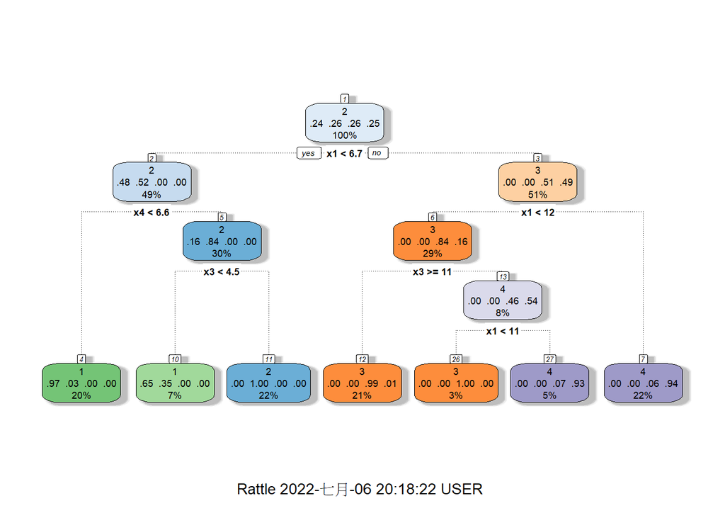

**Confusion Matrix**

```r
knitr::kable(tree.test.table,row.names = TRUE)
```

|  | 1 | 2 | 3 | 4 |
| --- | --- | --- | --- | --- |
| 1 | 24 | 0 | 0 | 0 |
| 2 | 3 | 15 | 0 | 0 |
| 3 | 0 | 0 | 17 | 1 |
| 4 | 0 | 0 | 2 | 18 |

**Testing data accuracy**

```r
(success/400)*100
```

```
## [1] 89.5
```

### **Random Forest**

```r
success <-0

for(i in 1:5){

  com.train <- com[-com.num[[i]],]
  com.test <- com[com.num[[i]],]

  com.rf <- randomForest(type~., data = com.train,ntree=500)
  rf.test.pred <- predict(com.rf, newdata = com.test)
  rf.test.table <- table(com.test$type, rf.test.pred, dnn = c("actual", "pred"))
  correct.rf.test <- sum(diag(rf.test.table))
  correct.rf.test

  success <- success + correct.rf.test

}
```

**Confusion Matrix**

```r
knitr::kable(rf.test.table, row.names = TRUE)
```

|  | 1 | 2 | 3 | 4 |
| --- | --- | --- | --- | --- |
| 1 | 24 | 0 | 0 | 0 |
| 2 | 1 | 17 | 0 | 0 |
| 3 | 0 | 0 | 17 | 1 |
| 4 | 0 | 0 | 2 | 18 |

**Testing data accuracy**

```r
(success/400)*100
```

```
## [1] 94.5
```

### **SVM**

```r
success <-0

for(i in 1:5){

  com.train <- com[-com.num[[i]],]
  com.test <- com[com.num[[i]],]


  com.svm <- svm(type~., data = com.train)

  com.svm.pred <- predict(com.svm, com.test)
  svm.test.table <- table(com.test$type, com.svm.pred, dnn = c("actual", "predict"))
  correct.svm.test <- sum(diag(svm.test.table))
  correct.svm.test

  success <- success + correct.svm.test

}
```

**Confusion Matrix**

```r
knitr::kable(svm.test.table,row.names = TRUE)
```

|  | 1 | 2 | 3 | 4 |
| --- | --- | --- | --- | --- |
| 1 | 23 | 1 | 0 | 0 |
| 2 | 1 | 17 | 0 | 0 |
| 3 | 0 | 0 | 18 | 0 |
| 4 | 0 | 0 | 4 | 16 |

**Testing data accuracy**

```r
(success/400)*100
```

```
## [1] 95
```

### **LDA**

```r
success <- 0

for(i in 1:5){

  com.train <- com[-com.num[[i]],]
  com.test <- com[com.num[[i]],]

  com.lda <- lda(type ~., data = com.train)

  com.lda.pred <- predict(com.lda, newdata = com.test[,-1])$class
  lda.test.table <- table(com.test$type, com.lda.pred, dnn = c("actual", "predict"))
  correct.lda.test <- sum(diag(lda.test.table))
  correct.lda.test

  success <- success + correct.lda.test

}
```

**Confusion Matrix**

```r
knitr::kable(lda.test.table,row.names = TRUE)
```

|  | 1 | 2 | 3 | 4 |
| --- | --- | --- | --- | --- |
| 1 | 23 | 1 | 0 | 0 |
| 2 | 1 | 17 | 0 | 0 |
| 3 | 0 | 0 | 17 | 1 |
| 4 | 0 | 0 | 3 | 17 |

**Testing data accuracy**

```r
(success/400)*100
```

```
## [1] 96.25
```

## **Difficulty**

```r
d.num <- kfcv(dif, seed=1116, k = 5)
```

### **CART**

```r
success <-0

for(i in 1:5){

  d.train <- dif[-d.num[[i]],]
  d.test <- dif[d.num[[i]],]

  d.tree <- rpart(type ~., data = d.train)

  tree.test.pred <- predict(d.tree, newdata = d.test, type="class")
  tree.test.table <- table(d.test$type, tree.test.pred, dnn = c("actual", "predict"))
  correct.tree.test <- sum(diag(tree.test.table))
  correct.tree.test


  success <- success + correct.tree.test

}
```

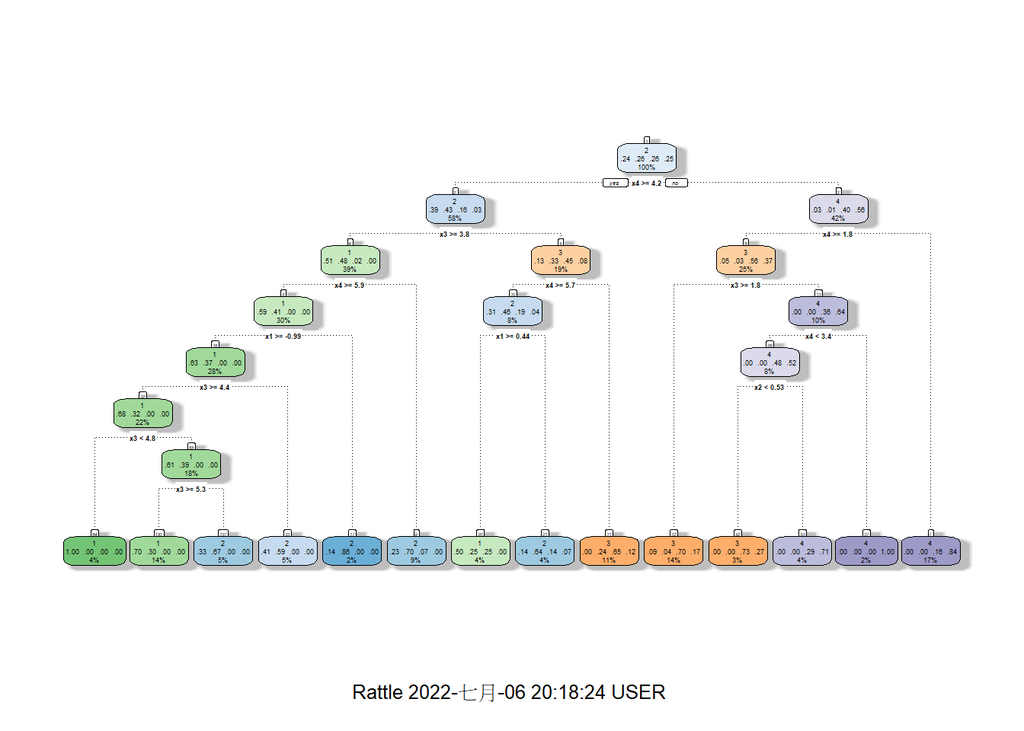

**Confusion Matrix**

```r
knitr::kable(tree.test.table,row.names = TRUE)
```

|  | 1 | 2 | 3 | 4 |
| --- | --- | --- | --- | --- |
| 1 | 11 | 13 | 0 | 0 |
| 2 | 7 | 9 | 2 | 0 |
| 3 | 0 | 2 | 8 | 8 |
| 4 | 0 | 0 | 5 | 15 |

**Testing data accuracy**

```r
(success/400)*100
```

```
## [1] 52.25
```

### **Random Forest**

```r
success <-0

for(i in 1:5){

  d.train <- dif[-d.num[[i]],]
  d.test <- dif[d.num[[i]],]

  d.rf <- randomForest(type~., data = d.train,ntree=500)
  rf.test.pred <- predict(d.rf, newdata = d.test)
  rf.test.table <- table(d.test$type, rf.test.pred, dnn = c("actual", "pred"))
  correct.rf.test <- sum(diag(rf.test.table))
  correct.rf.test

  success <- success + correct.rf.test

}
```

**Confusion Matrix**

```r
knitr::kable(rf.test.table, row.names = TRUE)
```

|  | 1 | 2 | 3 | 4 |
| --- | --- | --- | --- | --- |
| 1 | 10 | 14 | 0 | 0 |
| 2 | 11 | 5 | 2 | 0 |
| 3 | 0 | 1 | 8 | 9 |
| 4 | 0 | 0 | 5 | 15 |

**Testing data accuracy**

```r
(success/400)*100
```

```
## [1] 50
```

### **SVM**

```r
success <-0

for(i in 1:5){

  d.train <- dif[-d.num[[i]],]
  d.test <- dif[d.num[[i]],]


  d.svm <- svm(type~., data = d.train)

  d.svm.pred <- predict(d.svm, d.test)
  svm.test.table <- table(d.test$type, d.svm.pred, dnn = c("actual", "predict"))
  correct.svm.test <- sum(diag(svm.test.table))
  correct.svm.test

  success <- success + correct.svm.test

}
```

**Confusion Matrix**

```r
knitr::kable(svm.test.table,row.names = TRUE)
```

|  | 1 | 2 | 3 | 4 |
| --- | --- | --- | --- | --- |
| 1 | 13 | 11 | 0 | 0 |
| 2 | 9 | 7 | 2 | 0 |
| 3 | 0 | 1 | 10 | 7 |
| 4 | 0 | 0 | 5 | 15 |

**Testing data accuracy**

```r
(success/400)*100
```

```
## [1] 58.25
```

### **LDA**

```r
success <- 0

for(i in 1:5){

  d.train <- dif[-d.num[[i]],]
  d.test <- dif[d.num[[i]],]

  d.lda <- lda(type ~., data = d.train)

  d.lda.pred <- predict(d.lda, newdata = d.test[,-1])$class
  lda.test.table <- table(d.test$type, d.lda.pred, dnn = c("actual", "predict"))
  correct.lda.test <- sum(diag(lda.test.table))
  correct.lda.test

  success <- success + correct.lda.test

}
```

**Confusion Matrix**

```r
knitr::kable(lda.test.table,row.names = TRUE)
```

|  | 1 | 2 | 3 | 4 |
| --- | --- | --- | --- | --- |
| 1 | 12 | 12 | 0 | 0 |
| 2 | 9 | 7 | 2 | 0 |
| 3 | 0 | 0 | 10 | 8 |
| 4 | 0 | 0 | 4 | 16 |

**Testing data accuracy**

```r
(success/400)*100
```

```
## [1] 61.25
```

## **Unbalance**

```r
ub.num <- kfcv(ub, seed=1116, k = 5)
```

### **CART**

```r
success <-0

for(i in 1:5){

  ub.train <- ub[-ub.num[[i]],]
  ub.test <- ub[ub.num[[i]],]

  ub.tree <- rpart(type ~., data = ub.train)

  tree.test.pred <- predict(ub.tree, newdata = ub.test, type = "class")
  tree.test.table <- table(ub.test$type, tree.test.pred, dnn = c("actual", "predict"))
  correct.tree.test <- sum(diag(tree.test.table))
  correct.tree.test


  success <- success + correct.tree.test

}
```

[figure not shown]

**Confusion Matrix**

```r
knitr::kable(tree.test.table,row.names = TRUE)
```

|  | 1 | 2 | 3 | 4 |
| --- | --- | --- | --- | --- |
| 1 | 18 | 1 | 0 | 0 |
| 2 | 0 | 20 | 1 | 0 |
| 3 | 0 | 0 | 171 | 30 |
| 4 | 0 | 0 | 46 | 53 |

**Testing data accuracy**

```r
(success/1700)*100
```

```
## [1] 73.23529
```

### **Random Forest**

```r
success <-0

for(i in 1:5){

  ub.train <- ub[-ub.num[[i]],]
  ub.test <- ub[ub.num[[i]],]

  ub.rf <- randomForest(type~., data = ub.train,ntree=500)
  rf.test.pred <- predict(ub.rf, newdata = ub.test)
  rf.test.table <- table(ub.test$type, rf.test.pred, dnn = c("actual", "pred"))
  correct.rf.test <- sum(diag(rf.test.table))
  correct.rf.test

  success <- success + correct.rf.test

}
```

**Confusion Matrix**

```r
knitr::kable(rf.test.table, row.names = TRUE)
```

|  | 1 | 2 | 3 | 4 |
| --- | --- | --- | --- | --- |
| 1 | 18 | 1 | 0 | 0 |
| 2 | 0 | 21 | 0 | 0 |
| 3 | 0 | 0 | 168 | 33 |
| 4 | 0 | 0 | 44 | 55 |

**Testing data accuracy**

```r
(success/1700)*100
```

```
## [1] 74.94118
```

### **SVM**

```r
success <-0

for(i in 1:5){

  ub.train <- ub[-ub.num[[i]],]
  ub.test <- ub[ub.num[[i]],]


  ub.svm <- svm(type~., data = ub.train)

  ub.svm.pred <- predict(ub.svm, ub.test)
  svm.test.table <- table(ub.test$type, ub.svm.pred, dnn = c("actual", "predict"))
  correct.svm.test <- sum(diag(svm.test.table))
  correct.svm.test

  success <- success + correct.svm.test

}
```

**Confusion Matrix**

```r
knitr::kable(svm.test.table,row.names = TRUE)
```

|  | 1 | 2 | 3 | 4 |
| --- | --- | --- | --- | --- |
| 1 | 19 | 0 | 0 | 0 |
| 2 | 0 | 21 | 0 | 0 |
| 3 | 0 | 0 | 184 | 17 |
| 4 | 0 | 0 | 55 | 44 |

**Testing data accuracy**

```r
(success/1700)*100
```

```
## [1] 77.11765
```

### **LDA**

```r
success <- 0

for(i in 1:5){

  ub.train <- ub[-ub.num[[i]],]
  ub.test <- ub[ub.num[[i]],]

  ub.lda <- lda(type ~., data = ub.train)

  ub.lda.pred <- predict(ub.lda, newdata = ub.test[,-1])$class
  lda.test.table <- table(ub.test$type, ub.lda.pred, dnn = c("actual", "predict"))
  correct.lda.test <- sum(diag(lda.test.table))
  correct.lda.test

  success <- success + correct.lda.test

}
```

**Confusion Matrix**

```r
knitr::kable(lda.test.table,row.names = TRUE)
```

|  | 1 | 2 | 3 | 4 |
| --- | --- | --- | --- | --- |
| 1 | 19 | 0 | 0 | 0 |
| 2 | 0 | 21 | 0 | 0 |
| 3 | 0 | 0 | 176 | 25 |
| 4 | 0 | 0 | 48 | 51 |

**Testing data accuracy**

```r
(success/1700)*100
```

```
## [1] 77.94118
```

# **V. Conclusion**

- Simple data accuracy is better than Common data
- Difficulty data accuracy is 50-61%
- Unbalance data accuracy average is 75.81%

# **References**

- [Multivariate Normal Data](https://mushroom11167.shinyapps.io/220622/)
- [Multivariate Normal Data (Diagonal covariance matrix)](https://mushroom11167.shinyapps.io/220601/)
- [Covariance Matrix](https://www.ibm.com/docs/en/spss-statistics/26.0.0?topic=statistics-covariance-structures)
- [R Shiny](https://mastering-shiny.org/index.html)
- [Classifying data using Support Vector Machines(SVMs) in R](https://reurl.cc/6Zkld6)
- [Random Forest](https://reurl.cc/o1XdVl)
- **R語言資料分析**：李仁鐘、李秋緣 著